# 1. Data Requirements Documentation

# Purpose of the Documentation

This documentation serves as a comprehensive guide for managing and utilizing data in a movie analysis project. It outlines the types of data needed, quality standards, and ethical considerations, ensuring that the project's goals are met effectively and responsibly.

# Data Elements

Each data element is crucial for a thorough understanding of the film industry and for conducting detailed analyses. Here's a breakdown of these elements:

## Identify Data Types

### 1. Numerical Data

## a. Box Office Figures

- Description: Financial figures about the movies
- Units: Dollars
- Range: From low-budget independent films to high-budget blockbusters
- Importance: Essential for financial analysis and understanding audience reception.
- Source: flixpatrol api
- Quality standards: The data from FlixPatrol is recognized for its high quality, as FlixPatrol is a reputable source known for aggregating accurate and reliable box office figures. Their data collection methodology adheres to industry standards, ensuring the data's validity and trustworthiness.
- Ethical Considerations: The data will be accurary represented avoiding biasses in analysis.
- Project Relevance: Box office figures are a primary indicator of a movie's commercial success. Analyzing this data helps in evaluating the financial performance of films across different budgets, genres, and markets. ## b. Production Budgets
- Description: Financial data detailing the cost incurred to produce a movie.
- Units: Dollars
- Range: Covers a wide spectrum from low-budget independent films to high-budget blockbusters.
- importance: Critical for analyzing the financial investment behind movies and its correlation with box office success. Understanding production budgets helps in assessing the financial risk and potential return on investment.
- Source: flixpatrol api
- Quality Standards: The data from FlixPatrol is recognized for its high quality, as FlixPatrol is a reputable source known for aggregating accurate and reliable box office figures. Their data collection methodology adheres to industry standards, ensuring the data's validity and trustworthiness.
- Ethical Considerations: The data will be accurary represented avoiding biasses in analysis.
- Project Relevance: Analyzing the relationship between production budgets and box office performance can reveal insights into what budget ranges tend to be most successful, aiding in budget planning for future projects. ## c. Ratings
- Description: Movie ratings provide a quantitative measure of a film's reception by audiences and critics.
- Units: Typically on a scale of 0-10 or 0-100, depending on the rating system used by different platforms.
- Range: Ratings can vary from the lowest possible score (0 or 0%) to the highest (10 or 100%).
- Importance: Ratings are crucial for gauging audience and critic reactions to a film. They are often used as indicators of a movie's quality and popularity, influencing viewers' choices and industry perceptions.
- Source: Movie ratings are sourced from a variety of platforms, including IMDb, Rotten Tomatoes, Metacritic, and other critic review aggregators.
- Quality Standards: Ratings should represent a wide range of viewer opinions and critic reviews to avoid bias.
- Ethical Considerations: Ensure that the presentation of ratings does not misrepresent the general reception of the movie. Avoid cherry-picking data to support a preconceived narrative.
- Project relevance: AI can use audience and critic ratings to predict a movie's success, as high ratings often correlate with higher box office earnings and broader audience appeal.

### 2. Categorical Data

## a. Genres

- Description: Classification of movies based on their thematic and stylistic content.
- Categories: Encompasses a wide range of genres such as Action, Drama, Comedy, Thriller, Romance, Science Fiction, Horror, and others.
- Importance: Genres are crucial for understanding audience preferences, market segmentation, and for conducting targeted marketing and distribution strategies. They also play a significant role in thematic analysis and in predicting potential audience appeal.
- Source: Genre classifications are typically sourced from movie databases like IMDb, industry reports, and production studios. Streaming platforms also categorize their content by genre, providing an additional source of data.
- Quality Standards: Ensure consistency in genre classification across different sources. Include a broad spectrum of genres to cover diverse movie types.
- Ethical Considerations: Avoid subjective bias in genre categorization. Genres should be assigned based on content rather than personal interpretation. Acknowledging and fairly representing diverse genres, including those that might appeal to niche audiences.
- Project Relevance: Understanding genre trends can be vital for predictive modeling, as certain genres may perform better in different market conditions or geographical regions. Genres play a significant role in audience analysis, helping to identify potential viewers and tailor content to specific audience preferences.

## b. MPAA Ratings

- Description: The Motion Picture Association of America (MPAA) rating system classifies films based on their suitability for different audiences, primarily considering factors such as violence, language, sexual content, and thematic elements.
- Categories: The MPAA ratings include G (General Audiences), PG (Parental Guidance Suggested), PG-13 (Parents Strongly Cautioned), R (Restricted), and NC-17 (Adults Only).
- Importance: MPAA ratings are crucial for understanding the target audience of a film and for guiding parental decisions on movie suitability for children. They also play a significant role in market segmentation and can impact a film's distribution and marketing strategy.
- Source: The ratings are officially assigned by the Classification and Rating Administration (CARA), a division of the MPAA. These ratings are typically available on official movie websites, promotional materials, and film databases like IMDb.
- Quality Standards: Ensuring that the correct MPAA rating is associated with each film. Maintain consistency in how ratings are recorded and reported across different platforms and databases.
- Ethical Considerations: Responsibly representing the MPAA ratings without altering or misinterpreting them. It's important to convey the content advisories accurately to respect viewers' informed choices.
- Project Relevance: MPAA ratings can help AI models understand a movie's target demographic, which is crucial in predicting its success in specific audience segments.

## c. Release Types

- Description: This data categorizes movies based on their mode of distribution and release. It refers to how a film is made available to the public, whether through theaters, streaming platforms, television broadcasts, or direct-to-DVD options.
- Categories: The main categories include Theatrical Release (released in cinemas), Streaming Release (released on digital platforms like Netflix, Amazon Prime), Direct-to-DVD (released directly for home viewing), and Television Broadcast (released on TV channels).
- Importance: Understanding the release type is essential for market analysis, audience reach assessment, and strategic planning for marketing and distribution. Different release types can significantly affect a movie's revenue, audience size, and overall success.
- Source: Release type information is typically available from production studios' announcements, movie databases (such as IMDb), industry reports, and streaming service listings.
- Quality Standards: Clear and accurate categorization of each film's release type. Including all major types of releases to capture the full range of distribution methods in the modern film industry.
- Ethical Considerations: Ensuring each movie is fairly represented in terms of its release type, avoiding any bias towards or against a particular distribution method. -Project Relevance: Analyzing release types (theatrical, streaming, etc.) can inform AI about different market dynamics and distribution strategies, which significantly impact a movie's financial success.

### Text Data

## a. Movie Titles

- Description: Movie Titles are the official names given to films, used for identification, marketing, and reference. They are a fundamental component of a movie's identity and often carry significant meaning or association related to the film's content.
- Units: Typically composed of words or phrases; can include numbers or special characters.
- Range: Varies greatly, from single-word titles to longer phrases. Some titles may include subtitles or additional descriptors.
- Importance: Essential for the basic identification of movies. Crucial for categorization, searchability, and archival purposes.
- Source: Sourced from official movie databases like IMDb, film studios' press releases, movie marketing materials, and film festival listings.
- Quality Standards: Ensuring that the title accurately reflects the officially released name of the movie.Maintaining uniformity in how titles are recorded, especially for movies with alternative or international titles.
- Ethical Considerations: Acknowledging that movie titles are often trademarked or copyrighted and should be used with respect for these rights. Ensuring that titles are not altered in a way that misleads or misrepresents the film's content or themes.
- Project Relevance: Movie titles are key for organizing databases and retrieving specific films for analysis.

## b. Synopses

- Description: Movie Synopses provide a brief overview of a film’s plot, characters, and major themes. They offer a concise summary of the narrative, setting, and key elements of the story.
- Length: Varies considerably, from a few sentences to a detailed paragraph.
- Importance: Useful for content classification, thematic analysis, and identifying key story elements.
- Source: Sourced from official movie websites, promotional materials, film databases like IMDb, and press releases from production studios.
- Quality Standards: Ensuring that the synopsis correctly reflects the film’s content, without misleading or incorrect information.
- Ethical Considerations: Synopses should be used in a way that respects the creative work of filmmakers and writers, avoiding any form of plagiarism or in a way that wont reveal key plot twists or endings that could spoul the film
- Project Relevance: AI can analyze synopses for themes and genre elements to predict a movie's genre and potential audience, which are important factors in its success.

## c. Reviews

- Description: Critical and audience feedback on movies, encompassing opinions, ratings, and qualitative analysis.
- Units: Typically text-based; ratings may be on a scale (e.g., 1-5, 1-10).
- Range: From brief user comments to extensive professional critiques.
- Importance: Vital for gauging public perception and critical reception of movies. Influences audience choices and industry reputation.
- Source: Critic websites (e.g., Rotten Tomatoes), audience feedback on online platforms, film blogs, and newspapers.
- Quality Standards: Ensuring reviews are sourced from credible critics and genuine audiences and to capture a broad range of opinions to avoid biased perspectives.
- Ethical Considerations: Presenting reviews objectively without manipulating sentiments.
- Project Relevance: AI can analyze reviews for sentiment and thematic trends, offering insights into what aspects viewers and critics value or criticize, which can correlate with a movie's success.

## d. Personnel Names

- Description: Names of individuals involved in the making of a film, including directors, actors, writers, and other crew members.
- Units: Text-based, individual names.
- Range: Encompasses a wide array of roles and positions in the film industry.
- Importance: Key for credit attribution, tracking career trajectories, and analyzing industry networks.
- Source: Movie credits, industry databases (e.g., IMDb), production studio records.
- Quality Standards: Correct and complete recording of names and affiliations.
- Ethical Considerations: Ensuring accurate and fair crediting of all personnel.
- Project Relevance: The involvement of certain directors, actors, or writers can significantly influence a movie's success. AI can analyze the track record of these personnel to predict the potential success of their new projects.

### Image Data

## a. Movie Posters

- Description: Official promotional posters for films, used for advertising and marketing purposes. They typically feature key imagery, the film's title, taglines, and principal cast and crew names.
- Resolution: High resolution is crucial for clarity, especially for large-format printing and digital displays. Common resolutions include 300 dpi or higher for print and 1080p to 4K for digital formats.
- Range: The design varies widely, from minimalist art to complex, character-rich compositions. Styles can vary greatly depending on the genre and marketing strategy.
- Importance: Central to a film’s marketing campaign, often creating the first visual impression for the audience.
- Source: Primarily obtained from film production companies and official movie websites.
- Quality Standards: Ensuring high resolution and visual fidelity for accurate representation.
- Ethical Considerations: Strictly following copyright laws, using posters only with proper authorization or under fair use provisions.
- Project Relevance: Movie posters are often the first point of visual contact between the movie and its potential audience. An AI model can analyze elements like color palette, imagery, and design layout to determine patterns that are more likely to attract viewers, potentially influencing a film's success.

## b. Film Stills

- Description: Film Stills are high-quality photographs taken from the movie, capturing significant moments, characters, or scenes. They are often used for promotional purposes, in media coverage, and for archival documentation.
- Resolution: High-resolution images are essential for clarity and detail. This is particularly important for print media and high-definition digital displays. Common standards include 1080p, 2K, or 4K resolutions.
- Range: Includes a variety of shots, from close-ups of characters to wide shots of key scenes. The range also encompasses different moods, settings, and pivotal moments in the film.
- Importance: Crucial for visual marketing and generating audience interest.
- Source: Typically sourced from the production studios’ press kits and official movie websites.
- Quality Standards: Ensuring that film stills are of high visual quality and accurately represent the scenes from the movie.
- Ethical Considerations: Adherence to copyright laws and permissions, especially when using stills for commercial or promotional purposes.
- Project Relevance: Film stills can be analyzed using computer vision techniques to extract features like color schemes, presence of certain objects or characters, and scene composition. These features can potentially correlate with audience preferences and box office performance.

# 2. Data Collection Process

## Overview

The data for this project was collected using the Flixpatrol API, which provides comprehensive data on movie and TV show rankings, ratings, and earnings and also web scraping tools to collect additional data like revenue and cast and director information. Custom Python scripts were developed to interface with the API, request data, and process the responses.

## Collection Methodology

### API Access and Usage

## API Endpoints:

- Title details are accessed using endpoints like https://flixpatrol.com/api/v1.4/title/?id=XXXXX&api=YOUR_API_KEY, where XXXXX represents the title ID.
- To find a title’s ID, we browse the Flixpatrol website (e.g., https://flixpatrol.com/title/the-flash-2023/) and locate the ID near the title name.

### Python Scripts

- **Scripting Language**: Python 3.8
- **Libraries Used**: `requests` for API calls, `pandas` for data manipulation, and `json` for JSON response handling.
- **Error Handling**: Implemented try-except blocks to handle potential API errors and ensure robust data collection.

### Data Request Process

- **Request Frequency**: Daily requests were made to collect the latest data.
- **Parameters**: Parameters such as `date`, `region`, and `category` were configured to retrieve the required datasets.
- **Rate Limiting**: Requests were spaced to comply with the API's rate-limiting guidelines.

### Data Storage

- **Data Format**: Data was stored in CSV format for ease of use and compatibility.
- **File Naming**: Files were named systematically to include the date and type of data (`boxoffice`, `data`, `cast`).
- **Storage Location**: Data files were stored on a secure server with regular backups to prevent data loss.

### Data Processing

- **Initial Cleaning**: Preliminary data cleaning was performed to remove any obvious inaccuracies or incomplete records.
- **Data Transformation**: The data was transformed into a uniform format.
- **Combining Datasets**: Multiple datasets collected over time were combined into a single master file for each category of data.

## Automation

-There isn't any automation for the scripts.

## Compliance and Security

- **Data Protection**: All data was handled in compliance with GDPR and other relevant data protection laws.
- **Access Control**: Access to the collected data was restricted to authorized personnel only.

## Documentation

- **Code Documentation**: The Python scripts used for the data collection were well-documented with comments explaining the logic and methodology. The document is in the submition.

## Future Considerations

- **Scalability**: The data collection process was designed to be scalable with the addition of new data sources or expansion of data types.
- **Updates**: The scripts are maintained to accommodate any changes in the Flixpatrol API structure or rate limits.

# 3. Data Understanding

Here I am going to explore datasets that contain movie information, make visualizations and make conclusions for the next step. I will merge the datasets and see if there are any rows left out if not I will analyze the datasets combined.

```python
import pandas as pd
import matplotlib.pyplot as plt
import seaborn as sns

# Load the datasets
boxoffice_df = pd.read_csv('./boxOffice.csv')
data_df = pd.read_csv('./movies.csv')
director_dataset = pd.read_csv('./merged_movies_with_cast_director_and_id.csv')


# First merge: boxOffice.csv with movies.csv
first_merge = pd.merge(boxoffice_df, data_df, left_on='film_id_imdb', right_on='imdb', how='inner')

# Second merge: Merging the result with merged_movies_with_cast_director_and_id.csv
final_merge = pd.merge(first_merge, director_dataset, on='id', how='inner')
final_merge.head(10)
```

|  | name_x | film_id | film_id_imdb | film_id_tmdb | US only | International | Total | Production Budget | id | imdb | ... | keyword_id | keyword | company_id | company | rating_imdb | rating_rt | rating_flixpatrol | Movie | Cast | Director |
| --- | --- | --- | --- | --- | --- | --- | --- | --- | --- | --- | --- | --- | --- | --- | --- | --- | --- | --- | --- | --- | --- |
| 0 | Avatar | 306 | 499549 | 19995 | 785221649 | 2138484377 | 2923706026 | 237000000.0 | 306 | 499549 | ... | 9450.0 | Space opera | 949.0 | 20th Century | 79.0 | 82.0 | 164203.0 | Avatar | Sam Worthington, Zoe Saldana, Sigourney Weaver... | James Cameron |
| 1 | Avengers: Endgame | 49682 | 4154796 | 299534 | 858373000 | 1941066100 | 2799439100 | 400000000.0 | 49682 | 4154796 | ... | 229.0 | Marvel | 1124.0 | Marvel Studios | 84.0 | 94.0 | 147147.0 | Avengers: Endgame | Robert Downey Jr., Chris Evans, Mark Ruffalo, ... | Joe Russo, Anthony Russo |
| 2 | Avatar: The Way of Water | 59474 | 1630029 | 76600 | 680525032 | 1629261577 | 2309786609 | 460000000.0 | 59474 | 1630029 | ... | 9450.0 | Space opera | 949.0 | 20th Century | 76.0 | 76.0 | 144228.0 | Avatar: The Way of Water | Sam Worthington, Zoe Saldana, Sigourney Weaver... | James Cameron |
| 3 | Star Wars: The Force Awakens | 9 | 2488496 | 140607 | 936662225 | 1134647993 | 2071310218 | NaN | 9 | 2488496 | ... | 9450.0 | Space opera | 1175.0 | Lucasfilm | 78.0 | 93.0 | 1478.0 | Star Wars: The Force Awakens | Harrison Ford, Mark Hamill, Carrie Fisher, Dai... | J.J. Abrams |
| 4 | Avengers: Infinity War | 13768 | 4154756 | 299536 | 678815482 | 1369544272 | 2048359754 | 300000000.0 | 13768 | 4154756 | ... | 229.0 | Marvel | 1124.0 | Marvel Studios | 84.0 | 85.0 | 34164.0 | Avengers: Infinity War | Robert Downey Jr., Chris Hemsworth, Mark Ruffa... | Joe Russo, Anthony Russo |
| 5 | Spider-Man: No Way Home | 93502 | 10872600 | 634649 | 814115070 | 1107732041 | 1921847111 | 200000000.0 | 93502 | 10872600 | ... | 229.0 | Marvel | 1124.0 | Marvel Studios | 82.0 | 93.0 | 263820.0 | Spider-Man: No Way Home | Tom Holland, Zendaya, Benedict Cumberbatch, Ja... | Jon Watts |
| 6 | Titanic | 927 | 120338 | 597 | 600683057 | 1242690261 | 1843373318 | 200000000.0 | 927 | 120338 | ... | 240.0 | Disaster | 949.0 | 20th Century | 79.0 | 88.0 | 43110.0 | Titanic | Kate Winslet, Leonardo DiCaprio, Frances Fishe... | James Cameron |
| 7 | Jurassic World | 276 | 369610 | 135397 | 652270625 | 1018130012 | 1670400637 | 215000000.0 | 276 | 369610 | ... | 256.0 | Dinosaurs | 435.0 | Universal Pictures | 69.0 | 71.0 | 39299.0 | Jurassic World | Chris Pratt, Bryce Dallas Howard, Judy Greer, ... | Colin Trevorrow |
| 8 | The Lion King | 58193 | 6105098 | 420818 | 543638043 | 1119437358 | 1663075401 | 260000000.0 | 58193 | 6105098 | ... | 8742.0 | Animals | 508.0 | Walt Disney Pictures | 68.0 | 52.0 | 10488.0 | The Lion King | Donald Glover, Beyoncé Knowles, James Earl Jon... | Jon Favreau |
| 9 | The Lion King | 58193 | 6105098 | 420818 | 543638043 | 1119437358 | 1663075401 | 260000000.0 | 58193 | 6105098 | ... | 8742.0 | Animals | 508.0 | Walt Disney Pictures | 68.0 | 52.0 | 10488.0 | The Lion King | Jonathan Taylor Thomas, Matthew Broderick, Jam... | Roger Allers, Rob Minkoff |

10 rows × 30 columns

```python
count = final_merge["film_id"].value_counts()
count
```

```
129297    4
129296    4
140762    3
138183    3
14417     3
         ..
55199     1
93500     1
115185    1
104822    1
121432    1
Name: film_id, Length: 4093, dtype: int64
```

For some reason there are multiple movies that are repeating so I will drop them.

```python
final_merge = final_merge.drop_duplicates(subset='film_id')
count = final_merge["film_id"].value_counts()
count
```

```
306       1
132469    1
59177     1
127075    1
116155    1
         ..
13740     1
2471      1
13739     1
2570      1
121432    1
Name: film_id, Length: 4093, dtype: int64
```

Before continuing further I am going to make sure that dataset has a column for premiere month and that the data is appropriately structured for analysis. This will come handy further down the line when the machine learning part comes up.

```python
# Ensure 'premiere_date' is in datetime format to extract the premiere month
final_merge['premiere_date'] = pd.to_datetime(final_merge['premiere'], errors='coerce')
final_merge['premiere_month'] = final_merge['premiere_date'].dt.month
```

We will now analyze how the total revenue of movies varies with the month of release. This analysis can reveal if certain months are more favorable for movie releases, potentially due to seasonal audience behaviors, holidays, or other factors.

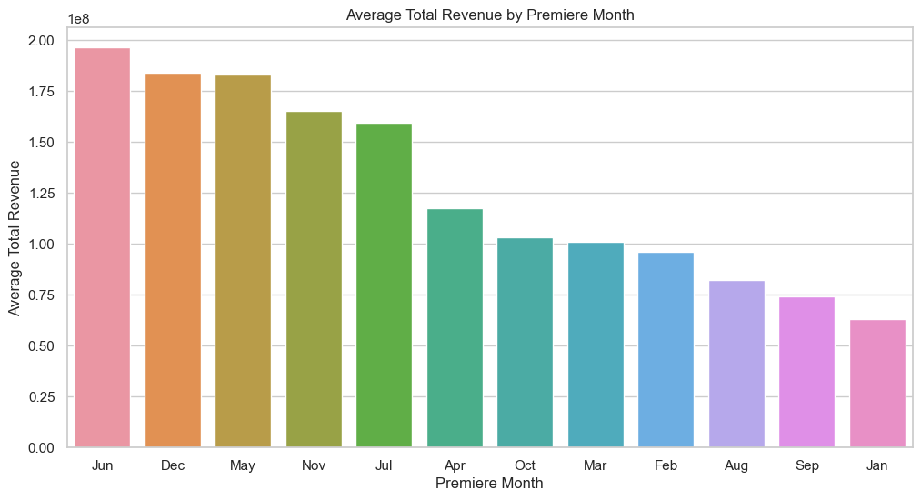

```python
import calendar

# Grouping data by premiere month and calculating the average total revenue
monthly_performance = final_merge.groupby('premiere_month')['Total'].mean().reset_index()

# Sorting the data by Total revenue in descending order for plotting
monthly_performance = monthly_performance.sort_values('Total', ascending=False)

# Visualizing the average total revenue by premiere month with the highest on the left
plt.figure(figsize=(12, 6))
sns.barplot(x='premiere_month', y='Total', data=monthly_performance, order=monthly_performance['premiere_month'])
plt.title('Average Total Revenue by Premiere Month')
plt.xlabel('Premiere Month')
plt.ylabel('Average Total Revenue')
plt.xticks(ticks=range(len(monthly_performance['premiere_month'])),
           labels=[calendar.month_abbr[month] for month in monthly_performance['premiere_month']])
plt.show()
```

Conclusion: The analysis underscores the pivotal role of release timing in determining a movie's success at the box office. The data indicates that the peak months of May, June, November, and December are particularly lucrative, aligning with holiday seasons and periods of higher audience availability, which historically result in increased box office revenue. However, the strategic selection of release dates, taking into account competitive factors and audience preferences, is essential. This involves not just targeting the high-revenue months but also considering the potential benefits of releasing films during less crowded periods to avoid competition with major blockbusters. The findings emphasize that a well-planned release schedule, attuned to market dynamics and audience trends, is key to maximizing a film's commercial success. Further steps that are going to be taken is to create out of this a feature that is going to be used for the machine learning part.

Now I will make a series of visualizations to better understand the distributions and relationships within our datasets.

#### Histogram for 'US only' Box Office Figures

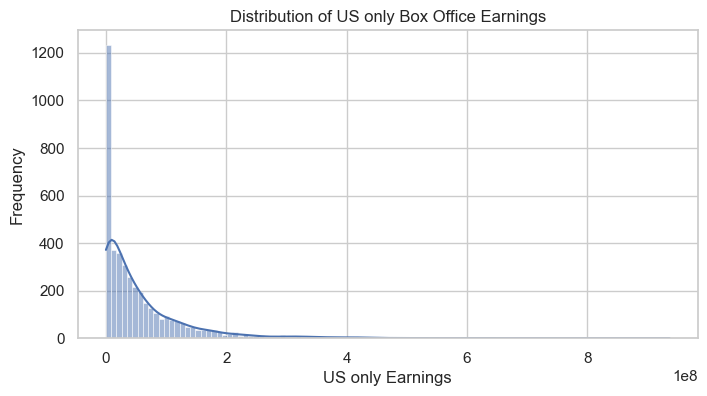

```python
import matplotlib.pyplot as plt
import seaborn as sns
import pandas as pd

# Load the dataset
boxoffice_df = pd.read_csv('./boxOffice.csv')

# Setting the aesthetic style of the plot
sns.set(style="whitegrid")

plt.figure(figsize=(8, 4))
sns.histplot(boxoffice_df['US only'].dropna(), kde=True)
plt.title('Distribution of US only Box Office Earnings')
plt.xlabel('US only Earnings')
plt.ylabel('Frequency')
plt.show()
```

#### Skewed Distribution

This histogram shows a right-skewed distribution for 'US only' box office earnings. It indicates that while a majority of movies earn less, a few achieve exceptionally high domestic earnings.

### Histogram for 'International' Box Office Figures

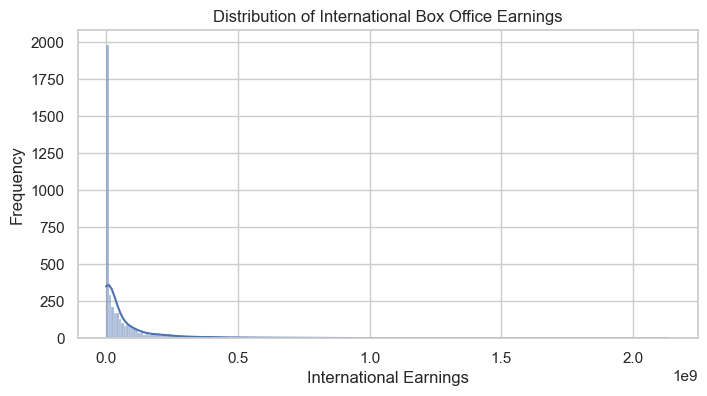

```python
plt.figure(figsize=(8, 4))
sns.histplot(boxoffice_df['International'].dropna(), kde=True)
plt.title('Distribution of International Box Office Earnings')
plt.xlabel('International Earnings')
plt.ylabel('Frequency')
plt.show()
```

### Skewed Distribution

Similar to the 'US only' earnings, the 'International' box office histogram also exhibits a right-skewed distribution. This pattern shows that international commercial success is limited to a small number of films.

### Histogram for 'Total' Box Office Figures

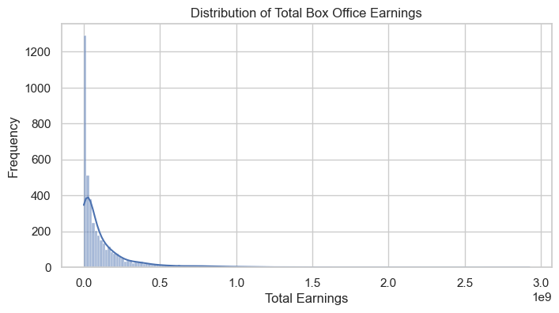

```python
plt.figure(figsize=(8, 4))
sns.histplot(boxoffice_df['Total'].dropna(), kde=True)
plt.title('Distribution of Total Box Office Earnings')
plt.xlabel('Total Earnings')
plt.ylabel('Frequency')
plt.show()
```

### Insight on Movie Success

The right-skewed distribution in the 'Total' box office earnings histogram reflects that only a select number of movies reach significant commercial success globally.

#### Histogram for 'Production Budget'

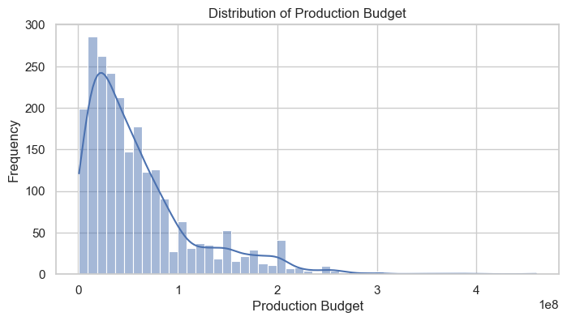

```python
plt.figure(figsize=(8, 4))
sns.histplot(boxoffice_df['Production Budget'].dropna(), kde=True)
plt.title('Distribution of Production Budget')
plt.xlabel('Production Budget')
plt.ylabel('Frequency')
plt.show()
```

### Budget Distribution

Most movies operate with moderate budgets, as shown by the right-skewed distribution in the 'Production Budget' histogram. High-budget films are relatively rare.

### Histogram for 'rating_imdb'

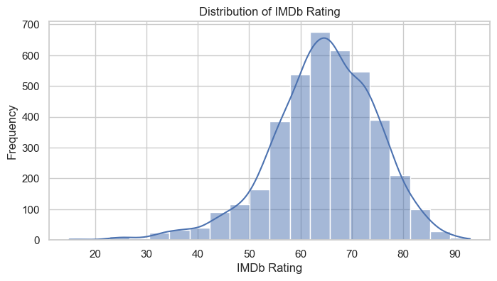

```python
# Load the dataset
data_df = pd.read_csv('./movies.csv')

plt.figure(figsize=(8, 4))
sns.histplot(data_df['rating_imdb'].dropna(), kde=True, bins=20)
plt.title('Distribution of IMDb Rating')
plt.xlabel('IMDb Rating')
plt.ylabel('Frequency')
plt.show()
```

### Histogram for 'rating_rt'

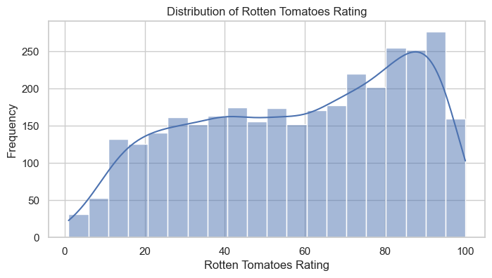

```python
plt.figure(figsize=(8, 4))
sns.histplot(data_df['rating_rt'].dropna(), kde=True, bins=20)
plt.title('Distribution of Rotten Tomatoes Rating')
plt.xlabel('Rotten Tomatoes Rating')
plt.ylabel('Frequency')
plt.show()
```

### Rating Distribution

#### Histogram for 'rating_flixpatrol'

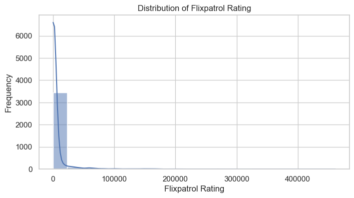

```python
plt.figure(figsize=(8, 4))
sns.histplot(data_df['rating_flixpatrol'].dropna(), kde=True, bins=20)
plt.title('Distribution of Flixpatrol Rating')
plt.xlabel('Flixpatrol Rating')
plt.ylabel('Frequency')
plt.show()
```

### Scatter Plot for Production Budget vs Total Box Office Earnings

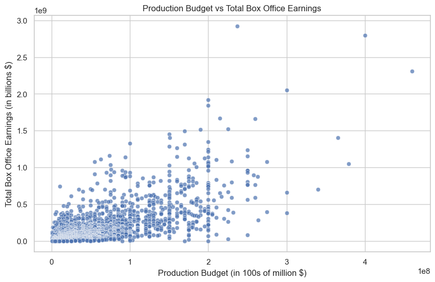

```python
plt.figure(figsize=(10, 6))
sns.scatterplot(data=boxoffice_df, x='Production Budget', y='Total', alpha=0.7)
plt.title('Production Budget vs Total Box Office Earnings')
plt.xlabel('Production Budget (in 100s of million $)')
plt.ylabel('Total Box Office Earnings (in billions $)')
plt.show()
```

### Positive Correlation

The scatter plot illustrates a general positive correlation between production budget and total box office earnings. However, the relationship is not strictly linear, and there are notable exceptions.

### High Budget, High Earnings

Some high-budget movies achieve substantial total earnings, which aligns with common expectations in the film industry.

### Variability in Success

The variability in the data points highlights that a high budget does not always guarantee high earnings, indicating the risk involved in movie production.

### Conclusions from the Visualizations

### Commercial Success

A small number of films achieve high commercial success, as evidenced by the skewness in the box office earnings distributions.

### Budget vs Earnings

There is a trend suggesting that higher budgets lead to higher earnings, but this relationship is not definitive and shows considerable variability.

### Ratings Analysis

The distribution of ratings across different platforms shows a range of audience perceptions and preferences, with some platforms displaying more varied ratings than others.

# 4. Data preparation

This is the last step of phase 2. Here I am going to prepare the data for modelig. Firstly I am going to remove some of the columns because they are repeating. The columns in question are "id","imdb", tmdb and 'name_y'. Additionaly after dropping 'name_y' I will change "name_x" to only "name"

```python
final_merge = final_merge.drop(['id', 'imdb','tmdb','name_y'], axis=1)


# Rename 'name_x' to 'name'
final_merge = final_merge.rename(columns={'name_x': 'name'})
```

Next I am going to remove the column type and type_id because they don't offer any value or usefull information as only 2 movies are Tv shows and not movies.

```python
type_mapping = final_merge.groupby(['type_id', 'type']).size().reset_index(name='count')
print(type_mapping)
```

```
   type_id     type  count
0        1    Movie   4091
1        2  TV Show      2
```

```python
final_merge = final_merge.drop(['type_id', 'type'], axis=1)
```

### Handeling missing values

Since we are going to use the machine learning algorith random forest, I am going to need to impute or remove missing values, because it cannot handle NaN values directly. Let's see what are we missing.

```python
final_merge.isnull().sum()
```

```
name                    0
film_id                 0
film_id_imdb            0
film_id_tmdb            0
US only                 0
International           0
Total                   0
Production Budget    1848
url                     0
premiere                0
country_id            177
country               177
genre_id              181
genre                 181
keyword_id            769
keyword               769
company_id           1170
company              1170
rating_imdb           235
rating_rt             853
rating_flixpatrol     542
Movie                   0
Cast                    0
Director                0
premiere_date           0
premiere_month          0
dtype: int64
```

After identifying the presence of missing values in our datasets, our next objective is to discern the nature of this missingness. This will enable us to determine whether the data is Missing Completely At Random (MCAR), Missing At Random (MAR), or Missing Not At Random (MNAR). Understanding this distinction is vital as it directly influences our approach to handling missing data. To understand that I will use a corellation matrix.

```python
# To identify if the missing data is MCAR or MAR, we'll look for patterns in the missing values.
# Create a DataFrame indicating where NaN values are located
missing_df = final_merge.isnull()

# Calculate the correlation matrix for missingness between columns
missing_corr = missing_df.corr()

# Filter out near-zero correlations and non-NaN values (which are correlations with themselves)
significant_missing_corr = missing_corr[missing_corr.abs() > 0.1].fillna(0)

# Focus on the significant correlations only for discussion
significant_missing_corr = significant_missing_corr.loc[:, (significant_missing_corr != 0).any(axis=0)]
significant_missing_corr = significant_missing_corr.loc[(significant_missing_corr != 0).any(axis=1), :]

print(significant_missing_corr)
```

```
                   Production Budget  country_id   country  genre_id  \
Production Budget           1.000000    0.224672  0.224672  0.215589
country_id                  0.224672    1.000000  1.000000  0.818952
country                     0.224672    1.000000  1.000000  0.818952
genre_id                    0.215589    0.818952  0.818952  1.000000
genre                       0.215589    0.818952  0.818952  1.000000
keyword_id                  0.455984    0.429711  0.429711  0.447206
keyword                     0.455984    0.429711  0.429711  0.447206
company_id                  0.432192    0.330720  0.330720  0.324205
company                     0.432192    0.330720  0.330720  0.324205
rating_imdb                 0.236149    0.716846  0.716846  0.723395
rating_rt                   0.447077    0.281270  0.281270  0.269996
rating_flixpatrol           0.266931    0.444954  0.444954  0.536549

                      genre  keyword_id   keyword  company_id   company  \
Production Budget  0.215589    0.455984  0.455984    0.432192  0.432192
country_id         0.818952    0.429711  0.429711    0.330720  0.330720
country            0.818952    0.429711  0.429711    0.330720  0.330720
genre_id           1.000000    0.447206  0.447206    0.324205  0.324205
genre              1.000000    0.447206  0.447206    0.324205  0.324205
keyword_id         0.447206    1.000000  1.000000    0.675802  0.675802
keyword            0.447206    1.000000  1.000000    0.675802  0.675802
company_id         0.324205    0.675802  0.675802    1.000000  1.000000
company            0.324205    0.675802  0.675802    1.000000  1.000000
rating_imdb        0.723395    0.330294  0.330294    0.243658  0.243658
rating_rt          0.269996    0.509312  0.509312    0.448882  0.448882
rating_flixpatrol  0.536549    0.223595  0.223595    0.175597  0.175597

                   rating_imdb  rating_rt  rating_flixpatrol
Production Budget     0.236149   0.447077           0.266931
country_id            0.716846   0.281270           0.444954
country               0.716846   0.281270           0.444954
genre_id              0.723395   0.269996           0.536549
genre                 0.723395   0.269996           0.536549
keyword_id            0.330294   0.509312           0.223595
keyword               0.330294   0.509312           0.223595
company_id            0.243658   0.448882           0.175597
company               0.243658   0.448882           0.175597
rating_imdb           1.000000   0.336207           0.523278
rating_rt             0.336207   1.000000           0.291127
rating_flixpatrol     0.523278   0.291127           1.000000
```

###### Summary

The calculated correlation matrix from our missing data indicators has revealed insightful patterns:

- We observed perfect correlations (1.0) between 'country_id' and 'country', as well as 'genre_id' and 'genre'. This suggests that if one of these values is missing, the other is also missing, indicating these pairs of data are Missing At Random (MAR).
- A strong positive correlation between missingness in 'genre_id'/'genre' and 'rating_imdb' (over 0.7) indicates a potential MAR pattern. When genre information is missing, there is a high chance that IMDb ratings are also missing, which could point to specific types of movies more prone to missing data.
- Other variables such as 'keyword_id', 'keyword', 'company_id', and 'company' also exhibit significant correlations with each other. This could indicate that certain information about movies is systematically absent, further supporting the MAR hypothesis.
- The low to moderate correlations between these variables and 'rating_rt' and 'rating_flixpatrol' ratings suggest that while there is some relationship between missingness across these variables, it is not as strong as within the previously mentioned pairs.

#### Next Steps:

These correlation patterns among missing values are crucial in guiding our missing data handling strategy. They suggest that we will apply different imputation methods for different variables or even consider collecting more data where possible.

In the case of the 'Production Budget' missing values, we will explore imputation methods that take into account the distribution of the known budget values, possibly using predictive modeling or leveraging known relationships with other variables such as 'Total' revenue.

For the movies, given the MAR nature of missingness, we will look into multivariate imputation techniques that can use the complete variables to estimate the missing ones. However, due to the perfect correlation in missingness between 'country_id' and 'country' as well as 'genre_id' and 'genre', we might consider whether retaining both of these variables is necessary, or if one can be excluded to simplify our dataset without losing information.

As we move forward, our data cleaning process will carefully consider these patterns to ensure that our dataset is as robust and complete as possible for the subsequent stages of analysis.

Now I will handle the missing data in the ratings.

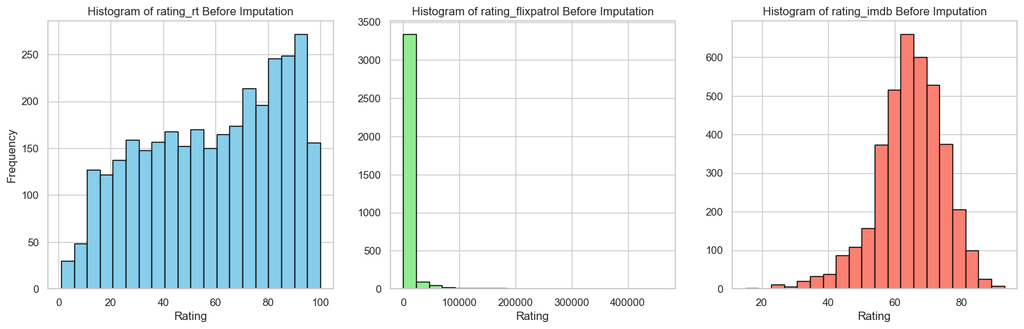

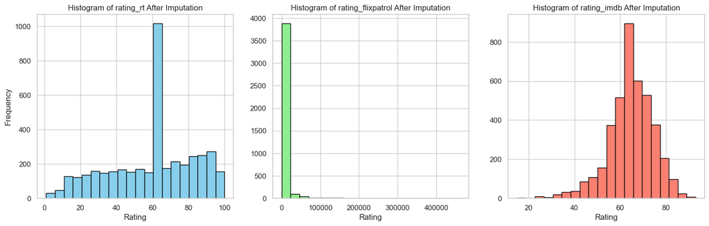

```python
import pandas as pd
import matplotlib.pyplot as plt

# Plot histograms before imputation
plt.figure(figsize=(18, 5))

plt.subplot(1, 3, 1)
plt.hist(final_merge['rating_rt'].dropna(), bins=20, color='skyblue', edgecolor='black')
plt.title('Histogram of rating_rt Before Imputation')
plt.xlabel('Rating')
plt.ylabel('Frequency')

plt.subplot(1, 3, 2)
plt.hist(final_merge['rating_flixpatrol'].dropna(), bins=20, color='lightgreen', edgecolor='black')
plt.title('Histogram of rating_flixpatrol Before Imputation')
plt.xlabel('Rating')

plt.subplot(1, 3, 3)
plt.hist(final_merge['rating_imdb'].dropna(), bins=20, color='salmon', edgecolor='black')
plt.title('Histogram of rating_imdb Before Imputation')
plt.xlabel('Rating')

plt.show()  # Display the figure with histograms before imputation

# Impute missing values using the median
final_merge['rating_rt'].fillna(final_merge['rating_rt'].median(), inplace=True)
final_merge['rating_flixpatrol'].fillna(final_merge['rating_flixpatrol'].median(), inplace=True)
final_merge['rating_imdb'].fillna(final_merge['rating_imdb'].median(), inplace=True)

# Plot histograms after imputation
plt.figure(figsize=(18, 5))

plt.subplot(1, 3, 1)
plt.hist(final_merge['rating_rt'], bins=20, color='skyblue', edgecolor='black')
plt.title('Histogram of rating_rt After Imputation')
plt.xlabel('Rating')
plt.ylabel('Frequency')

plt.subplot(1, 3, 2)
plt.hist(final_merge['rating_flixpatrol'], bins=20, color='lightgreen', edgecolor='black')
plt.title('Histogram of rating_flixpatrol After Imputation')
plt.xlabel('Rating')

plt.subplot(1, 3, 3)
plt.hist(final_merge['rating_imdb'], bins=20, color='salmon', edgecolor='black')
plt.title('Histogram of rating_imdb After Imputation')
plt.xlabel('Rating')

plt.show()  # Display the figure with histograms after imputation
```

### Decision Against Imputation:

- Imputing missing ratings such as 'rating_rt', 'rating_flixpatrol', and 'rating_imdb' using the median could result in a dataset that does not accurately reflect the reality of the movie industry, where success is multifaceted and can be influenced by factors not captured in our dataset.
- Given the goal of our analysis is to predict movie success accurately, introducing any form of bias could compromise the validity of our predictive models and the conclusions drawn from them.

### Chosen Course of Action:

```python
data_cleaned = final_merge.dropna(subset=['rating_imdb', 'rating_rt', 'rating_flixpatrol'], how='all')

data_cleaned.to_csv('./droppedMissingRatings.csv', index=False)
```

###### Mode Imputation for `country_id`

Here's the process we followed:

1. **Identify the Mode**: We computed the mode of the `country_id` column to find the most common value.
2. **Drop Missing Values**: Instead of filling these gaps with the mode, we removed all rows with missing country_id values. This approach ensures that no artificial bias is introduced to the dataset, as mode imputation might overrepresent the most common value.
3. **Validation**: WWe visualized the data distribution of country_id before dropping the missing values to understand the original data structure. After removing the missing values, we refrained from visualizing the distribution as it would not provide meaningful insight due to reduced data volume.

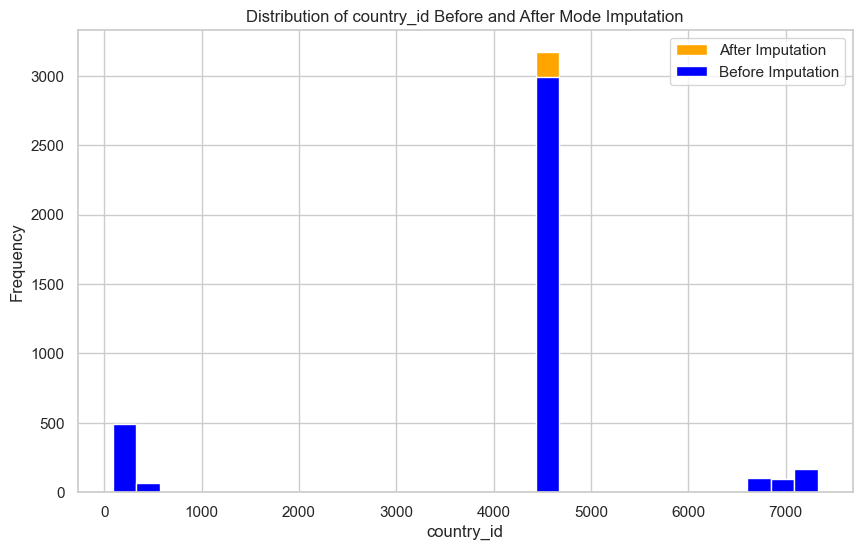

```python
import matplotlib.pyplot as plt
import pandas as pd

# Load the dataset
data_with_missing = pd.read_csv('./droppedMissingRatings.csv')

# Calculate the mode of the 'country_id' column and impute missing values
country_id_mode = data_with_missing['country_id'].mode()[0]
data_with_missing['country_id_filled'] = data_with_missing['country_id'].fillna(country_id_mode)

# Plotting
plt.figure(figsize=(10, 6))
plt.hist(data_with_missing['country_id_filled'], bins=30, color='orange', alpha=1, label='After Imputation')
plt.hist(data_with_missing['country_id'].dropna(), bins=30, color='blue', alpha=1, label='Before Imputation')

plt.title('Distribution of country_id Before and After Mode Imputation')
plt.xlabel('country_id')
plt.ylabel('Frequency')
plt.legend()
plt.show()
```

## Conclusion

Upon examining the distribution of country_id before and after imputation, it is evident that the imputation has led to an artificial inflation of the mode's frequency. While the rest of the distribution appears relatively unchanged, the prominence of the mode post-imputation may not accurately reflect the true underlying pattern of the data. Given this distortion, it may be more prudent to consider deleting the missing values, especially if the mode's overrepresentation could lead to biased analyses or if the missingness is not random but informative. This approach should, of course, be weighed against the loss of data and potential reduction in sample size.

```python
# Drop the rows where 'country_id' is missing
data_without_missing = data_with_missing.dropna(subset=['country_id'])

# Save the dataset without missing values
data_without_missing.to_csv('./droppedMissingCountry.csv', index=False)
```

Now lets fill the country names

```python
filled_company_data_path = './droppedMissingCountry.csv'
data_with_filled_country_id = pd.read_csv(filled_company_data_path)

# Create the mapping dictionary from 'country_id' to 'country'
country_mapping = data_with_filled_country_id.dropna(subset=['country_id', 'country'])\
                                             .drop_duplicates(subset='country_id')\
                                             .set_index('country_id')['country'].to_dict()

# Fill in the 'country' column using the mapping
data_with_filled_country_id['country'] = data_with_filled_country_id.apply(
    lambda row: country_mapping.get(row['country_id'], row['country']), axis=1
)

# Save the updated dataframe to a new CSV file
data_with_filled_country_id.to_csv('./filledCountryNames.csv', index=False)
```

## Filling NaN Values in 'genre_id' Column

### Process Overview:

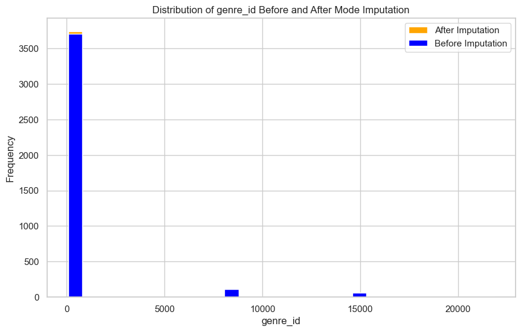

```python
import matplotlib.pyplot as plt
import pandas as pd

# Load the dataset
data_with_missing = pd.read_csv('./filledCountryNames.csv')

# Calculate the mode of the 'genre_id' column
genre_id_mode = data_with_missing['genre_id'].mode()[0]

# Impute missing values in 'genre_id' with the mode
data_with_missing['genre_id_filled'] = data_with_missing['genre_id'].fillna(genre_id_mode)

# Plotting
plt.figure(figsize=(10, 6))

# Plot histogram after filling in missing values
plt.hist(data_with_missing['genre_id_filled'], bins=30, color='orange', alpha=1, label='After Imputation')

# Overlaying histograms - Plot histogram before filling in missing values
plt.hist(data_with_missing['genre_id'].dropna(), bins=30, color='blue', alpha=1, label='Before Imputation')

plt.title('Distribution of genre_id Before and After Mode Imputation')
plt.xlabel('genre_id')
plt.ylabel('Frequency')
plt.legend()

plt.show()
```

###### Conclusion:

After evaluating the 'genre_id' column, it was determined that the missing values would be dropped rather than imputed with the most frequent genre ID. This decision was made to maintain the integrity of the dataset and avoid introducing potential biases that might occur with mode imputation. Removing these records ensures that our analysis is only based on complete cases with original genre IDs, thereby preserving the validity of any subsequent data analysis and manipulation. While this may result in a reduction of the dataset size, it prevents the distortion of the genre distribution which could affect the outcome of any data-driven insights.

```python
# Drop rows with missing 'genre_id' values
data_without_missing_genre = data_with_missing.dropna(subset=['genre_id'])

# Save the data with filled 'genre_id' to a new CSV file
data_without_missing_genre.to_csv('./droppedGen.csv', index=False)
```

###### Filling NaN Values in 'keyword_id' Column

### Process Overview:

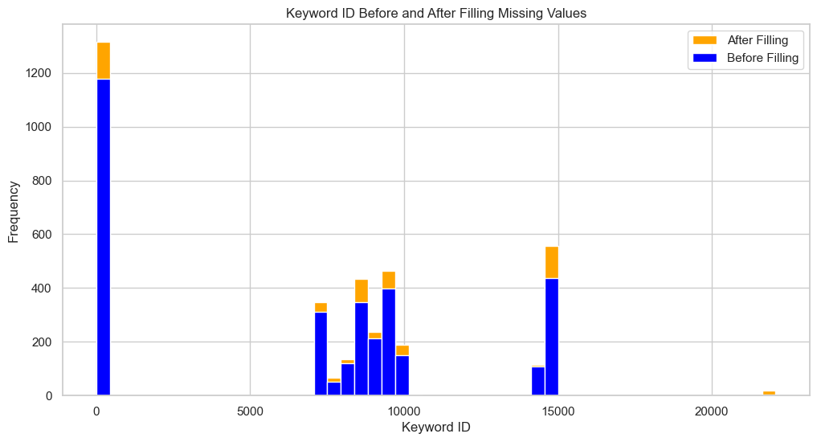

```python
import numpy as np

import pandas as pd
import matplotlib.pyplot as plt

# Load the data
file_path = './droppedGen.csv'
data = pd.read_csv(file_path)

# Extract existing keyword_id values
existing_keyword_ids = data['keyword_id'].dropna().unique()

# Randomly fill NaN values with existing keyword_id values
np.random.seed(0)  # For reproducibility
filled_keyword_ids = data['keyword_id'].apply(
    lambda x: np.random.choice(existing_keyword_ids) if np.isnan(x) else x
)

# Plot histograms for the 'keyword_id' before and after filling in missing values on the same axis
plt.figure(figsize=(12, 6))

# Plot histogram after filling in missing values
plt.hist(filled_keyword_ids, bins=50, color='orange', alpha=1, label='After Filling')

# Plot histogram before filling in missing values
plt.hist(data['keyword_id'].dropna(), bins=50, color='blue', alpha=1, label='Before Filling')

plt.title('Keyword ID Before and After Filling Missing Values')
plt.xlabel('Keyword ID')
plt.ylabel('Frequency')
plt.legend()
plt.show()
```

###### Conclusion:

```python
data_without_missing_keyword_id = data.dropna(subset=['keyword_id'])



data_without_missing_keyword_id.to_csv('./keyworddropped.csv', index=False)
```

Now lets do the same for Company ID

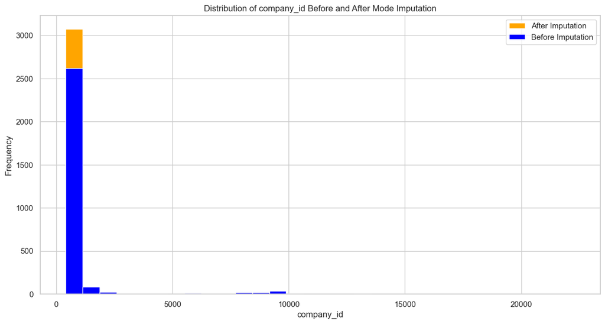

```python
import pandas as pd
import matplotlib.pyplot as plt

# Load the dataset into a DataFrame
data_with_missing = pd.read_csv('./keyworddropped.csv')

# Calculate the mode of the 'company_id' column
company_id_mode = data_with_missing['company_id'].mode()[0]

# Perform mode imputation and create a new column for the imputed values
data_with_missing['company_id_imputed'] = data_with_missing['company_id'].fillna(company_id_mode)

# Visualize the comparison before and after mode imputation using histograms
plt.figure(figsize=(14, 7))


# Create a histogram for 'company_id' after imputation
plt.hist(data_with_missing['company_id_imputed'], bins=30, color='orange', alpha=1, label='After Imputation')

# Create a histogram for 'company_id' before imputation
plt.hist(data_with_missing['company_id'].dropna(), bins=30, color='blue', alpha=1, label='Before Imputation')


# Add plot title, labels, and legend
plt.title('Distribution of company_id Before and After Mode Imputation')
plt.xlabel('company_id')
plt.ylabel('Frequency')
plt.legend()

# Display the plot
plt.show()
```

```python
# Drop rows with missing 'company_id' values
data_without_missing_company = data_with_missing.dropna(subset=['company_id'])

# Save the data with filled 'company_id' to a new CSV file
data_without_missing_company.to_csv('./droppedCompanyId.csv', index=False)
```

Now lets fill the missing company names

```python
import pandas as pd

# Load the dataset
data_with_filled_company_id = pd.read_csv('./droppedCompanyId.csv')

# Create the mapping dictionary from 'company_id' to 'company'
company_mapping = data_with_filled_company_id.dropna(subset=['company_id', 'company'])\
                                             .drop_duplicates(subset='company_id')\
                                             .set_index('company_id')['company'].to_dict()

# Fill in the 'company' column using the mapping
data_with_filled_company_id['company'] = data_with_filled_company_id.apply(
    lambda row: company_mapping.get(row['company_id'], row['company']), axis=1
)

# Save the updated dataframe to a new CSV file
data_with_filled_company_id.to_csv('./filledMissingCompanyNames.csv', index=False)
```

### Conclusion

The mode imputation filled the missing values significantly altering the overall distribution of 'company_id'. This approach is suitable for categorical data where using the most frequent value is a logical choice for imputation. However, the implications of this increase in the frequency of the mode value changes the strcuture of the dataset and the rows with missing values will be removed to avoid biases.

## KNN Imputation for Production Budget Data

In addressing the missing 'Production Budget' entries in our `boxoffice_df` dataset, we have elected to use a K Nearest Neighbors (KNN) imputation method. This technique allows us to infer missing values using the most similar entries based on other features, which helps to reduce the potential for bias compared to simpler imputation methods.

##### Rationale for KNN Imputation:

- **Nearest Neighbors Approach**: KNN Imputation utilizes the surrounding neighbors of a data point to estimate a missing value. By setting `n_neighbors=3`, we use the three nearest neighbors to predict the missing 'Production Budget' values.
- **Preserving Data Relationships**: This method is particularly suitable for our dataset as it can preserve the intrinsic relationships between different numerical features, making the imputed values more reliable.

### Imputation Process:

1. We initiated the KNN Imputer specifying three neighbors to influence the imputation for each missing value.
2. We applied the imputer to our numerical columns only, as KNN works on the principle of distance which is most appropriate for continuous data.
3. The imputer then calculated the nearest neighbors for each entry with a missing 'Production Budget' and estimated the missing values based on those neighbors.

### Visual Confirmation:

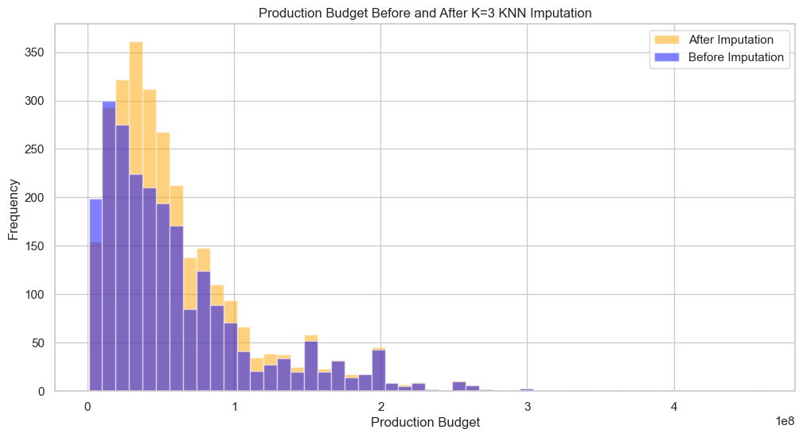

```python
import pandas as pd
import matplotlib.pyplot as plt
from sklearn.impute import KNNImputer

# Load datasets
filled_company_id_df = pd.read_csv('./droppedCompanyId.csv')

# Merge datasets using a common identifier

# Specify columns for imputation
columns_for_imputation = ['Production Budget', 'country_id', 'genre_id', 'keyword_id', 'company_id', 'rating_imdb', 'rating_rt', 'rating_flixpatrol']
knn_imputer = KNNImputer(n_neighbors=3)

# Apply KNN Imputation
filled_company_id_df[columns_for_imputation] = knn_imputer.fit_transform(filled_company_id_df[columns_for_imputation])

plt.figure(figsize=(12, 6))

# Plot histogram after KNN imputation
plt.hist(filled_company_id_df['Production Budget'], bins=50, color='orange', alpha=0.5, label='After Imputation')

# Plot histogram before KNN imputation
plt.hist(boxoffice_df['Production Budget'].dropna(), bins=50, color='blue', alpha=0.5, label='Before Imputation')

plt.title('Production Budget Before and After K=3 KNN Imputation')
plt.xlabel('Production Budget')
plt.ylabel('Frequency')
plt.legend()
plt.show()
```

# Conclusion from Histogram Analysis of 'Production Budget' Imputation

## Reassessment of KNN Imputation Efficacy

The visual analysis of the 'Production Budget' data before and after KNN imputation has led to a significant revelation. The histogram comparison, depicted in the provided diagram, indicates that the distribution post-imputation does not align with the original data as closely as previously believed.

## Impact of Imputation on Data Characteristics

A visual inspection suggests that the KNN imputation with `k=3` has introduced a discrepancy in the distribution, particularly in the lower ranges of the budget. This is evident from the overlay of histograms where the frequencies of certain budget ranges have been noticeably altered.

## Decision Against Imputation

In light of these visual discrepancies and the potential for misrepresenting the data, it has been concluded that KNN imputation is not a suitable method for handling missing 'Production Budget' values in this context. The introduction of imputed values may distort the authentic financial landscape of the dataset, which is paramount for accurate analysis.

## Proceeding with Complete Cases

Therefore, the decision has been made to proceed with the analysis using only those entries that have complete 'Production Budget' data. This choice ensures the retention of the dataset's integrity and the reliability of subsequent analyses.

## Final Decision

Despite the initial appearance of successful imputation, the visual evidence and the imperative to preserve data accuracy have led to the decision to exclude movies without budget data from the dataset. This approach safeguards the validity of our financial analysis, allowing us to draw conclusions with greater confidence in the data's veracity.

Here I will drop the columns that were created durring the data inputation and drop the rows with missing production bugded.

```python
import pandas as pd

# Load the original datasets
filled_company_id_df = pd.read_csv('./droppedCompanyId.csv')

# Merge the datasets

# Drop the specified columns
columns_to_drop = [ 'company_id_imputed', 'genre_id_filled', 'country_id_filled']
filled_company_id_df = filled_company_id_df.drop(columns=columns_to_drop)

# Drop rows where 'Production Budget' is missing or zero
merged_df_cleaned = filled_company_id_df.dropna(subset=['Production Budget'])
merged_df_cleaned = merged_df_cleaned[merged_df_cleaned['Production Budget'] != 0]

# Save the cleaned dataset to a new CSV file
merged_df_cleaned.to_csv('./mergedCleanedNoImputation.csv', index=False)
print(merged_df_cleaned)
```

```
                          name  film_id  film_id_imdb  film_id_tmdb  \
0                       Avatar      306        499549         19995
1            Avengers: Endgame    49682       4154796        299534
2     Avatar: The Way of Water    59474       1630029         76600
4       Avengers: Infinity War    13768       4154756        299536
5      Spider-Man: No Way Home    93502      10872600        634649
...                        ...      ...           ...           ...
2810            Blood and Wine    37155        115710         31640
2826                 I Origins     5816       2884206        244267
2827              The Gray Man   106905       1649418        725201
2842             Human Traffic     3370        188674         11129
2859                     Dumbo     5925         33563         11360

        US only  International       Total  Production Budget  \
0     785221649     2138484377  2923706026        237000000.0
```

[output cut: 77 more lines]

# 5. Preprocesing

## Phase 3

Here I will preprocess the data so it could be better read by the computer. For now I will start adding new features because from the previous iteration we concluded that we can increase the accuracy by implementing new features from the current ones.

#### Categorizing Premiere Month as a Feature

To enhance the predictive accuracy of our machine learning model, we will categorize the `premiere_month` into distinct groups based on observed revenue trends. This categorization will help the model to recognize and leverage the patterns associated with movie releases in different months of the year. The months will be categorized as follows:

- **High Revenue Months:** May, June, November, and December, typically associated with major holiday seasons and high audience turnout.
- **Moderate Revenue Months:** April, July, and October, which have shown strong performance but not as pronounced as the high revenue months.
- **Low Revenue Months:** Months that traditionally show lower revenues, including January, August, and September, possibly due to off-peak industry times.

```python
# Categorizing 'premiere_month' into 'High Revenue Months', 'Moderate Revenue Months', and 'Low Revenue Months'

def categorize_premiere_month(month):
    if month in [5, 6, 11, 12]:  # High Revenue Months
        return 'High Revenue'
    elif month in [4, 7, 10]:  # Moderate Revenue Months
        return 'Moderate Revenue'
    else:  # Low Revenue Months
        return 'Low Revenue'

# Applying the categorization function to the 'premiere_month' column
merged_df_cleaned['premiere_month_category'] = merged_df_cleaned['premiere_month'].apply(categorize_premiere_month)

# Displaying the first few rows to see the new categorization
merged_df_cleaned[['premiere_month', 'premiere_month_category']].head()
```

|  | premiere_month | premiere_month_category |
| --- | --- | --- |
| 0 | 12 | High Revenue |
| 1 | 4 | Moderate Revenue |
| 2 | 12 | High Revenue |
| 4 | 4 | Moderate Revenue |
| 5 | 12 | High Revenue |

Now let's see what what interaction do other features in the dataset have. I will see what the interaction between Genre and Premiere Month Category Interaction is.

### Genre and Premiere Month Category Interaction Analysis

With the categorization of premiere months into 'High Revenue', 'Moderate Revenue', and 'Low Revenue' categories, we will now explore the interaction between movie genres and these premiere month categories. This analysis aims to uncover how the performance of different genres varies in different types of months, providing insights into the optimal release timing for genres.

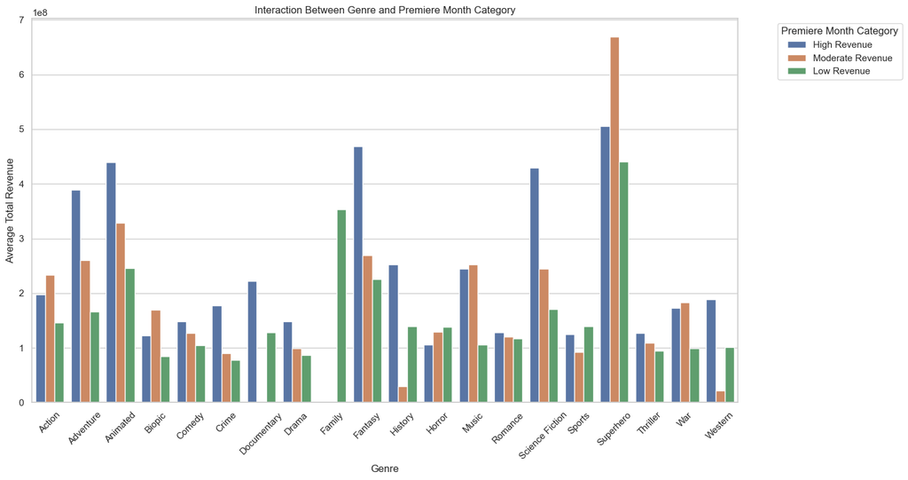

```python
# Ensure that 'premiere_month_category' is of categorical type with the desired order
merged_df_cleaned['premiere_month_category'] = pd.Categorical(
    merged_df_cleaned['premiere_month_category'],
    categories=['High Revenue', 'Moderate Revenue', 'Low Revenue'],
    ordered=True
)

# Grouping data by genre and premiere month category to calculate average total revenue
genre_month_interaction = merged_df_cleaned.groupby(['genre', 'premiere_month_category'])['Total'].mean().reset_index()

# Visualizing the interaction between genre and premiere month category
plt.figure(figsize=(15, 8))
sns.barplot(x='genre', y='Total', hue='premiere_month_category', data=genre_month_interaction, hue_order=['High Revenue', 'Moderate Revenue', 'Low Revenue'])
plt.title('Interaction Between Genre and Premiere Month Category')
plt.xticks(rotation=45)
plt.xlabel('Genre')
plt.ylabel('Average Total Revenue')
plt.legend(title='Premiere Month Category', bbox_to_anchor=(1.05, 1), loc='upper left')
plt.tight_layout()
plt.show()
```

#### Interaction Analysis: Genre and Premiere Month Category

The bar plot visualizes the interaction between movie genres and their categorized premiere months (High Revenue, Moderate Revenue, and Low Revenue Months). This analysis aims to uncover patterns in how different genres perform financially during various types of months.

### Strategic Insights for Film Industry:

Now I will implement Seasonal Genre Popularity Feature. This feature aims to reflect how popular or successful different genres are in specific seasons of the year, based on historical data. By incorporating this feature, we can provide our model with more context about the potential performance of a movie, taking into account when it is released and what genre it belongs to.

##### Steps for Implementing the Feature:

Define Seasons:

- We will categorize the year into four seasons - Winter, Spring, Summer, and Fall. These seasons will be based on the months of the year, aligning with common movie release patterns.

Analyze Historical Popularity/Revenue:

- We will calculate the average revenue or popularity for each genre within each defined season. This analysis helps in understanding which genres perform better in which seasons, based on historical trends.

Create the Seasonal Genre Popularity Feature:

- Using the insights from the analysis, we will create a new feature for each movie that quantifies the historical popularity of its genre in the season it was released.

The following code executes these steps, adding new features to our dataset that capture the essence of how different genres fare across different seasons.

```python
# Define the seasons
def assign_season(month):
    if month in [12, 1, 2]:
        return 'Winter'
    elif month in [3, 4, 5]:
        return 'Spring'
    elif month in [6, 7, 8]:
        return 'Summer'
    else:  # 9, 10, 11
        return 'Fall'

# Assign season to each movie
merged_df_cleaned['season'] = merged_df_cleaned['premiere_month'].apply(assign_season)

# Calculate average revenue for each genre in each season
seasonal_genre_revenue = merged_df_cleaned.groupby(['genre', 'season'])['Total'].mean().reset_index()

# Normalize the revenue within each genre
max_revenue_per_genre = seasonal_genre_revenue.groupby('genre')['Total'].transform('max')
seasonal_genre_revenue['normalized_revenue'] = seasonal_genre_revenue['Total'] / max_revenue_per_genre

# Pivot the table for easier feature creation
pivot_table = seasonal_genre_revenue.pivot(index='genre', columns='season', values='normalized_revenue').fillna(0)

# Create the feature in the original dataframe
for season in pivot_table.columns:
    merged_df_cleaned[f'genre_popularity_{season}'] = merged_df_cleaned['genre'].map(pivot_table[season])

# Now merged_df contains the new features
print(merged_df_cleaned.head(10))
```

```
                        name  film_id  film_id_imdb  film_id_tmdb    US only  \
0                     Avatar      306        499549         19995  785221649
1          Avengers: Endgame    49682       4154796        299534  858373000
2   Avatar: The Way of Water    59474       1630029         76600  680525032
4     Avengers: Infinity War    13768       4154756        299536  678815482
5    Spider-Man: No Way Home    93502      10872600        634649  814115070
6                    Titanic      927        120338           597  600683057
7             Jurassic World      276        369610        135397  652270625
8              The Lion King    58193       6105098        420818  543638043
9               The Avengers      119        848228         24428  623357910
10                 Furious 7        4       2820852        168259  353007020

    International       Total  Production Budget  \
0      2138484377  2923706026        237000000.0
1      1941066100  2799439100        400000000.0
```

[output cut: 70 more lines]

Something interesting here to note is that some movies that have been released on a specific season can have higher genre popularity for a different season. This is because genre popularity scores are derived from historical trends across all movies in the dataset. It's possible that movies of the same genre generally performed best in a different season, historically.

```python
from sklearn.preprocessing import LabelEncoder

# Split and explode 'Cast' and 'Director'
exploded_cast = merged_df_cleaned.assign(Cast=merged_df_cleaned['Cast'].str.split(', ')).explode('Cast')
exploded_directors = merged_df_cleaned.assign(Director=merged_df_cleaned['Director'].str.split(', ')).explode('Director')

# Calculate average box office earnings
cast_box_office_avg = exploded_cast.groupby('Cast')['Total'].mean()
director_box_office_avg = exploded_directors.groupby('Director')['Total'].mean()

# Frequency encoding
cast_frequency = exploded_cast['Cast'].value_counts()
director_frequency = exploded_directors['Director'].value_counts()

# Combine frequency with box office earnings
cast_combined_metric = cast_frequency * cast_box_office_avg
director_combined_metric = director_frequency * director_box_office_avg

# Aggregate metrics by movie and map back to original dataset
merged_df_cleaned['Enhanced_Cast_Metric'] = merged_df_cleaned['film_id'].map(exploded_cast.groupby('film_id')['Cast'].apply(lambda x: (cast_combined_metric[x].sum())))
merged_df_cleaned['Enhanced_Director_Metric'] = merged_df_cleaned['film_id'].map(exploded_directors.groupby('film_id')['Director'].apply(lambda x: (director_combined_metric[x].sum())))

# Label Encoding for Directors
le = LabelEncoder()
exploded_directors['Director_encoded'] = le.fit_transform(exploded_directors['Director'].astype(str))
merged_df_cleaned = merged_df_cleaned.merge(exploded_directors[['film_id', 'Director_encoded']].drop_duplicates(), on='film_id', how='left')

# View the last 100 rows of the dataset
merged_df_cleaned.tail(100)
```

|  | name | film_id | film_id_imdb | film_id_tmdb | US only | International | Total | Production Budget | url | premiere | ... | premiere_month | premiere_month_category | season | genre_popularity_Fall | genre_popularity_Spring | genre_popularity_Summer | genre_popularity_Winter | Enhanced_Cast_Metric | Enhanced_Director_Metric | Director_encoded |
| --- | --- | --- | --- | --- | --- | --- | --- | --- | --- | --- | --- | --- | --- | --- | --- | --- | --- | --- | --- | --- | --- |
| 2081 | Buffy the Vampire Slayer | 32720 | 103893 | 10206 | 16624456 | 0 | 16624456 | 7000000.0 | https://flixpatrol.com/title/buffy-the-vampire... | 7/24/1992 | ... | 7 | Moderate Revenue | Summer | 0.791016 | 0.615900 | 1.000000 | 0.685449 | 3.683710e+09 | 1.662446e+07 | 286 |
| 2082 | Battle of the Year | 5470 | 1532958 | 109417 | 8888355 | 7661122 | 16549477 | 20000000.0 | https://flixpatrol.com/title/battle-of-the-year/ | 9/21/2013 | ... | 9 | Low Revenue | Fall | 0.626878 | 0.710558 | 0.829610 | 1.000000 | 4.594727e+09 | 1.654948e+07 | 84 |
| 2083 | Trainspotting | 974 | 117951 | 627 | 16491080 | 0 | 16491080 | 3100000.0 | https://flixpatrol.com/title/trainspotting/ | 2/23/1996 | ... | 2 | Low Revenue | Winter | 0.626878 | 0.710558 | 0.829610 | 1.000000 | 5.995676e+09 | 6.932071e+08 | 184 |
| 2084 | A Simple Plan | 891 | 120324 | 10223 | 16316273 | 0 | 16316273 | 17000000.0 | https://flixpatrol.com/title/a-simple-plan/ | 12/11/1998 | ... | 12 | High Revenue | Winter | 1.000000 | 0.886728 | 0.851396 | 0.822313 | 4.458162e+09 | 3.542151e+09 | 809 |
| 2085 | Jason Goes to Hell: The Final Friday | 92178 | 107254 | 10285 | 15935068 | 0 | 15935068 | 3000000.0 | https://flixpatrol.com/title/jason-goes-to-hel... | 8/13/1993 | ... | 8 | Low Revenue | Summer | 0.791016 | 0.615900 | 1.000000 | 0.685449 | 4.402639e+08 | 1.593507e+07 | 5 |
| ... | ... | ... | ... | ... | ... | ... | ... | ... | ... | ... | ... | ... | ... | ... | ... | ... | ... | ... | ... | ... | ... |
| 2176 | I Origins | 5816 | 2884206 | 244267 | 336472 | 144762 | 481234 | 1000000.0 | https://flixpatrol.com/title/i-origins/ | 7/18/2014 | ... | 7 | Moderate Revenue | Summer | 0.626878 | 0.710558 | 0.829610 | 1.000000 | 9.157437e+08 | 4.812340e+05 | 636 |
| 2177 | The Gray Man | 106905 | 1649418 | 725201 | 0 | 454023 | 454023 | 200000000.0 | https://flixpatrol.com/title/the-gray-man-2022/ | 7/22/2022 | ... | 7 | Moderate Revenue | Summer | 0.768906 | 1.000000 | 0.929675 | 0.585363 | 2.044715e+10 | 1.369320e+10 | 426 |
| 2178 | The Gray Man | 106905 | 1649418 | 725201 | 0 | 454023 | 454023 | 200000000.0 | https://flixpatrol.com/title/the-gray-man-2022/ | 7/22/2022 | ... | 7 | Moderate Revenue | Summer | 0.768906 | 1.000000 | 0.929675 | 0.585363 | 2.044715e+10 | 1.369320e+10 | 55 |
| 2179 | Human Traffic | 3370 | 188674 | 11129 | 104257 | 0 | 104257 | 3300000.0 | https://flixpatrol.com/title/human-traffic/ | 6/4/1999 | ... | 6 | High Revenue | Summer | 0.626878 | 0.710558 | 0.829610 | 1.000000 | 7.297990e+05 | 1.042570e+05 | 508 |
| 2180 | Dumbo | 5925 | 33563 | 11360 | 0 | 3731 | 3731 | 170000000.0 | https://flixpatrol.com/title/dumbo/ | 10/23/1941 | ... | 10 | Moderate Revenue | Fall | 0.670195 | 0.979647 | 1.000000 | 0.644624 | 1.782766e+10 | 3.640514e+09 | 901 |

100 rows × 35 columns

Now I will implement a scorig system based on the interaction between movie genres and premiere month categories. This score aims to encapsulate the combined impact of a movie's genre and its premiere timing on expected revenue.

```python
average_revenue = merged_df_cleaned.groupby(['genre', 'premiere_month_category']).mean()['Total']
normalized_revenue = (average_revenue - average_revenue.min()) / (average_revenue.max() - average_revenue.min())
def assign_score(value):
    if value > 0.66:
        return 3
    elif value > 0.33:
        return 2
    else:
        return 1
scores = normalized_revenue.apply(assign_score)
merged_df_cleaned['genre_month_score'] = merged_df_cleaned.apply(lambda row: scores.get((row['genre'], row['premiere_month_category']), 1), axis=1)


merged_df_cleaned.head(10)
```

|  | name | film_id | film_id_imdb | film_id_tmdb | US only | International | Total | Production Budget | url | premiere | ... | premiere_month_category | season | genre_popularity_Fall | genre_popularity_Spring | genre_popularity_Summer | genre_popularity_Winter | Enhanced_Cast_Metric | Enhanced_Director_Metric | Director_encoded | genre_month_score |
| --- | --- | --- | --- | --- | --- | --- | --- | --- | --- | --- | --- | --- | --- | --- | --- | --- | --- | --- | --- | --- | --- |
| 0 | Avatar | 306 | 499549 | 19995 | 785221649 | 2138484377 | 2923706026 | 237000000.0 | https://flixpatrol.com/title/avatar-2009/ | 12/15/2009 | ... | High Revenue | Winter | 0.679136 | 0.803161 | 0.983836 | 1.000000 | 5.943731e+10 | 7.950568e+09 | 372 | 2 |
| 1 | Avengers: Endgame | 49682 | 4154796 | 299534 | 858373000 | 1941066100 | 2799439100 | 400000000.0 | https://flixpatrol.com/title/avengers-endgame/ | 4/24/2019 | ... | Moderate Revenue | Spring | 0.858342 | 1.000000 | 0.516768 | 0.620332 | 1.085209e+11 | 1.369320e+10 | 426 | 3 |
| 2 | Avengers: Endgame | 49682 | 4154796 | 299534 | 858373000 | 1941066100 | 2799439100 | 400000000.0 | https://flixpatrol.com/title/avengers-endgame/ | 4/24/2019 | ... | Moderate Revenue | Spring | 0.858342 | 1.000000 | 0.516768 | 0.620332 | 1.085209e+11 | 1.369320e+10 | 55 | 3 |
| 3 | Avatar: The Way of Water | 59474 | 1630029 | 76600 | 680525032 | 1629261577 | 2309786609 | 460000000.0 | https://flixpatrol.com/title/avatar-the-way-of... | 12/14/2022 | ... | High Revenue | Winter | 0.679136 | 0.803161 | 0.983836 | 1.000000 | 5.451233e+10 | 7.950568e+09 | 372 | 2 |
| 4 | Avengers: Infinity War | 13768 | 4154756 | 299536 | 678815482 | 1369544272 | 2048359754 | 300000000.0 | https://flixpatrol.com/title/avengers-infinity... | 4/25/2018 | ... | Moderate Revenue | Spring | 0.858342 | 1.000000 | 0.516768 | 0.620332 | 1.162451e+11 | 1.369320e+10 | 426 | 3 |
| 5 | Avengers: Infinity War | 13768 | 4154756 | 299536 | 678815482 | 1369544272 | 2048359754 | 300000000.0 | https://flixpatrol.com/title/avengers-infinity... | 4/25/2018 | ... | Moderate Revenue | Spring | 0.858342 | 1.000000 | 0.516768 | 0.620332 | 1.162451e+11 | 1.369320e+10 | 55 | 3 |
| 6 | Spider-Man: No Way Home | 93502 | 10872600 | 634649 | 814115070 | 1107732041 | 1921847111 | 200000000.0 | https://flixpatrol.com/title/spider-man-no-way... | 12/15/2021 | ... | High Revenue | Winter | 0.858342 | 1.000000 | 0.516768 | 0.620332 | 5.441791e+10 | 2.802014e+09 | 474 | 3 |
| 7 | Titanic | 927 | 120338 | 597 | 600683057 | 1242690261 | 1843373318 | 200000000.0 | https://flixpatrol.com/title/titanic-1997/ | 12/19/1997 | ... | High Revenue | Winter | 0.626878 | 0.710558 | 0.829610 | 1.000000 | 2.335491e+10 | 7.950568e+09 | 372 | 1 |
| 8 | Jurassic World | 276 | 369610 | 135397 | 652270625 | 1018130012 | 1670400637 | 215000000.0 | https://flixpatrol.com/title/jurassic-world/ | 6/12/2015 | ... | High Revenue | Summer | 0.679136 | 0.803161 | 0.983836 | 1.000000 | 2.605509e+10 | 1.670401e+09 | 167 | 2 |
| 9 | The Lion King | 58193 | 6105098 | 420818 | 543638043 | 1119437358 | 1663075401 | 260000000.0 | https://flixpatrol.com/title/the-lion-king-2019/ | 7/17/2019 | ... | Moderate Revenue | Summer | 0.457832 | 1.000000 | 0.705974 | 0.800122 | 2.422535e+10 | 4.896996e+09 | 468 | 2 |

10 rows × 36 columns

# Modeling

Now I will see and select which features I will use for the model.

[figure not shown]

```python
# Calculate correlations with numeric_only set to True
corr = merged_df_cleaned.corr()
# Increase the size of the figure
plt.figure(figsize=(18, 15))  # You can adjust the size as needed

# Create a heatmap with adjusted annotation font size
sns.heatmap(corr, annot=True, fmt=".2f", cmap='coolwarm', annot_kws={"size": 8},
            linewidths=.5, linecolor='gray')



plt.title("Heatmap of Numerical Movie Features")
plt.show()
```

#### Feature Selection Based on Domain Knowledge

In developing our predictive model to assess the success of movies, we have carefully chosen a set of features that are grounded in domain knowledge. This approach ensures that the factors we consider are not only statistically relevant but also contextually meaningful in the movie industry. Below are the details of our selected features and the rationale behind each:

#### Selected Features:

- country_id / country: Market Size and Influence: Films produced in countries with larger and more influential movie industries (like the U.S. or India) have a broader reach and higher potential for success. Production Budgets: Different countries have varying levels of investment in movie production, which impacts the quality and marketing of the film. Cultural Resonance: The cultural aspects inherent to the country of production can dictate the thematic and narrative style of the movie, influencing its acceptance in both domestic and international markets.
- genre_id: Audience Preferences: Different genres resonate differently across various audience segments. For instance, action movies perform well globally, while comedies see more success domestically due to cultural nuances. Market Trends: The popularity of certain genres fluctuates over time, reflecting changing audience tastes and market trends.
- keyword_id: Thematic Trends: Keywords can capture current trends in movie themes that resonate with audiences, like "superhero" or "dystopian". Niche Appeal: Certain keywords indicate a niche appeal which could lead to strong but possibly limited success in specific audience segments.
- company_id: Resource Availability: Larger companies have more resources for production and marketing, leading to potentially higher-quality films and better market penetration. Brand Recognition: The reputation of a production company influences audience expectations and trust, impacting a film's initial draw.
- premiere_year and premiere_month: Market Competition: Movies released during high competition periods (like summer or holiday seasons) face different challenges and opportunities compared to off-peak times. Seasonal Preferences: Certain genres do better in specific months, like horror in October or family movies during the holiday season.
- Enhanced_Cast_Metric: Star Power: Well-known actors significantly draw audiences, impacting box office revenues, especially in the opening weeks. Cast Synergy: The combination of cast members influences the film's appeal, where certain actor pairings or ensembles might attract more viewers.
- Enhanced_Director_Metric: Directorial Influence: A director with a strong track record or unique style is a major draw for audiences and can also influence the artistic quality of the film. Brand Association: Directors often carry a 'brand' that comes with certain expectations about film quality and genre, influencing audience choice.
- genre_month_score: Seasonal-Genre Alignment: This metric accounts for how well a genre performs in a particular month, acknowledging that some genres have seasonal appeal (e.g., romantic films around Valentine’s Day). Historical Trends: It also incorporates historical data, identifying patterns of success for specific genre-month combinations, which can be crucial for planning release strategies.

# Splitting into train/test

Now, we're preparing our data for analysis. 'X' includes various identifiers and metrics significant for movie success prediction, while 'Y' represents the target variable which is defined based on financial success and IMDb ratings.

```python
from sklearn.model_selection import train_test_split, RandomizedSearchCV
from sklearn.metrics import accuracy_score, classification_report, roc_auc_score
from sklearn.preprocessing import LabelEncoder
from sklearn.ensemble import RandomForestClassifier, GradientBoostingClassifier
from sklearn.linear_model import LogisticRegression
from sklearn.svm import SVC
from sklearn.tree import DecisionTreeClassifier
from sklearn.neighbors import KNeighborsClassifier
from sklearn.naive_bayes import GaussianNB
from sklearn.neural_network import MLPClassifier

# Parse the 'premiere' column to datetime
merged_df_cleaned['premiere_date'] = pd.to_datetime(merged_df_cleaned['premiere'], errors='coerce')

# Extract year and month from the premiere date
merged_df_cleaned['premiere_year'] = merged_df_cleaned['premiere_date'].dt.year
merged_df_cleaned['premiere_month'] = merged_df_cleaned['premiere_date'].dt.month

# Define features (X) including the premiere year and month, and target (y)
X = merged_df_cleaned[['country_id', 'genre_id','keyword_id','company_id','premiere_year', 'premiere_month', 'Enhanced_Cast_Metric','Enhanced_Director_Metric','genre_month_score']]


# Define the target variable based on the criteria
# 1 if successful, 0 if not successful
merged_df_cleaned['Success'] = (merged_df_cleaned['Total'] > merged_df_cleaned['Production Budget']) & (merged_df_cleaned['rating_imdb'] >= 7.0)
y = merged_df_cleaned['Success'].astype(int)  # Ensure the target is in integer format
```

```python
# Split data
X_train, X_test, y_train, y_test = train_test_split(X, y, test_size=0.2, random_state=1)
```

# Modeling

I am going to try a couple of models out and see which one will be the best choice for our dataset.

#### Logistic Regression Model

We start with Logistic Regression, a simple yet powerful model that predicts the probability of a binary outcome. It's particularly effective for linearly separable data. Here, we use it to determine the success of a movie based on various features.

```python
# Logistic Regression
logreg = LogisticRegression()
print("Training Logistic Regression...")
logreg.fit(X_train, y_train)
y_pred_logreg = logreg.predict(X_test)

# Evaluation Metrics for Logistic Regression
accuracy_logreg = logreg.score(X_test, y_test)
roc_auc_logreg = roc_auc_score(y_test, y_pred_logreg)
classification_report_logreg = classification_report(y_test, y_pred_logreg, zero_division=0)

print("Logistic Regression Results:")
print(f"Accuracy: {accuracy_logreg}")
print(f"ROC AUC: {roc_auc_logreg}")
print(f"Classification Report:\n{classification_report_logreg}\n")
```

```
Training Logistic Regression...
Logistic Regression Results:
Accuracy: 0.8672768878718535
ROC AUC: 0.5
Classification Report:
              precision    recall  f1-score   support

           0       0.00      0.00      0.00        58
           1       0.87      1.00      0.93       379

    accuracy                           0.87       437
   macro avg       0.43      0.50      0.46       437
weighted avg       0.75      0.87      0.81       437
```

##### SVM Model

Next, we use the SVM model, renowned for its high accuracy in classification problems. SVM works by finding a hyperplane that best separates the classes in the feature space.

```python
# Support Vector Machine (SVM)
svm = SVC()
print("Training SVM...")
svm.fit(X_train, y_train)
y_pred_svm = svm.predict(X_test)

# Evaluation Metrics for SVM
accuracy_svm = svm.score(X_test, y_test)
roc_auc_svm = roc_auc_score(y_test, y_pred_svm)
classification_report_svm = classification_report(y_test, y_pred_svm, zero_division=0)

print("SVM Results:")
print(f"Accuracy: {accuracy_svm}")
print(f"ROC AUC: {roc_auc_svm}")
print(f"Classification Report:\n{classification_report_svm}\n")
```

```
Training SVM...
SVM Results:
Accuracy: 0.8672768878718535
ROC AUC: 0.5
Classification Report:
              precision    recall  f1-score   support

           0       0.00      0.00      0.00        58
           1       0.87      1.00      0.93       379

    accuracy                           0.87       437
   macro avg       0.43      0.50      0.46       437
weighted avg       0.75      0.87      0.81       437
```

#### Random Forest

Random Forest is an ensemble method that operates by constructing multiple decision trees. It offers the benefit of handling both numerical and categorical data and is less prone to overfitting.

```python
# Random Forest
random_forest = RandomForestClassifier()
print("Training Random Forest...")
random_forest.fit(X_train, y_train)
y_pred_rf = random_forest.predict(X_test)

# Evaluation Metrics for Random Forest
accuracy_rf = random_forest.score(X_test, y_test)
roc_auc_rf = roc_auc_score(y_test, y_pred_rf)
classification_report_rf = classification_report(y_test, y_pred_rf, zero_division=0)

print("Random Forest Results:")
print(f"Accuracy: {accuracy_rf}")
print(f"ROC AUC: {roc_auc_rf}")
print(f"Classification Report:\n{classification_report_rf}\n")
```

```
Training Random Forest...
Random Forest Results:
Accuracy: 0.8947368421052632
ROC AUC: 0.6253525611864252
Classification Report:
              precision    recall  f1-score   support

           0       0.83      0.26      0.39        58
           1       0.90      0.99      0.94       379

    accuracy                           0.89       437
   macro avg       0.87      0.63      0.67       437
weighted avg       0.89      0.89      0.87       437
```

### Gradient Boosting Model

Gradient Boosting is another ensemble technique that builds trees in a sequential manner, where each tree tries to correct the errors made by the previous one.

```python
# Gradient Boosting
gradient_boosting = GradientBoostingClassifier()
print("Training Gradient Boosting...")
gradient_boosting.fit(X_train, y_train)
y_pred_gb = gradient_boosting.predict(X_test)

# Evaluation Metrics for Gradient Boosting
accuracy_gb = gradient_boosting.score(X_test, y_test)
roc_auc_gb = roc_auc_score(y_test, y_pred_gb)
classification_report_gb = classification_report(y_test, y_pred_gb, zero_division=0)

print("Gradient Boosting Results:")
print(f"Accuracy: {accuracy_gb}")
print(f"ROC AUC: {roc_auc_gb}")
print(f"Classification Report:\n{classification_report_gb}\n")
```

```
Training Gradient Boosting...
Gradient Boosting Results:
Accuracy: 0.8810068649885584
ROC AUC: 0.588231280138295
Classification Report:
              precision    recall  f1-score   support

           0       0.69      0.19      0.30        58
           1       0.89      0.99      0.93       379

    accuracy                           0.88       437
   macro avg       0.79      0.59      0.62       437
weighted avg       0.86      0.88      0.85       437
```

Now I will apply hyperparamer tuning to the random forest because it got the highest accuracy of them all. And this is an explanation of the parameters used:

n_estimators: Represents the number of trees in the forest for ensemble methods like RandomForest. np.arange(100, 1001, 50) means you are considering anywhere from 100 to 1000 trees, in steps of 50 (i.e., 100, 150, 200, ..., 1000).

max_depth: This is the maximum depth of each tree. None means there's no limit on the depth, and np.arange(5, 56, 5) means considering depths starting from 5 up to 55, in steps of 5. A deeper tree can capture more complex patterns but might also lead to overfitting.

min_samples_split: The minimum number of samples required to split an internal node in a tree. np.arange(2, 21, 2) means considering a minimum of 2 up to 20 samples, in steps of 2. Higher values prevent creating nodes that are too specific, which can help with overfitting.

min_samples_leaf: The minimum number of samples required to be at a leaf node. np.arange(1, 21, 2) means considering a minimum of 1 up to 20 samples, in steps of 2. Similar to min_samples_split, larger numbers prevent the model from learning overly specific patterns.

bootstrap: Whether bootstrap samples are used when building trees. If False, the whole dataset is used to build each tree. [True, False] means considering both options. True generally provides a better bias-variance tradeoff for ensemble methods.

max_features: The number of features to consider when looking for the best split. ['sqrt', 'log2'] means considering either the square root or the log base 2 of the total number of features. These are common heuristics to add randomness to the model and prevent overfitting.

criterion: The function to measure the quality of a split. ['gini', 'entropy'] are the two commonly used measures for the quality of a split. Gini impurity and entropy (information gain) are measures of how homogenous the nodes are after a split.

```python
# Expanded and modified parameter distribution
param_dist = {
    'n_estimators': np.arange(100, 1001, 50),  # Expanded range for the number of trees
    'max_depth': [None] + list(np.arange(5, 56, 5)),  # Expanded range for maximum depth
    'min_samples_split': np.arange(2, 21, 2),  # Wider range for min_samples_split
    'min_samples_leaf': np.arange(1, 21, 2),  # Wider range for min_samples_leaf
    'bootstrap': [True, False],  # Bootstrap samples for training
    'max_features': [ 'sqrt', 'log2'],  # Different options for max_features
    'criterion': ['gini', 'entropy'],  # Criteria for measuring the quality of a split

}





# Increased number of iterations for a broader search
random_search = RandomizedSearchCV(
   estimator=RandomForestClassifier(random_state=1),
    param_distributions=param_dist,

    # param_distributions - Dictionary with parameters names (str) as keys and distributions or lists of parameters to try.
    # Distributions must provide a rvs method for sampling (such as those from scipy.stats.distributions).
    # If a list is given, it is sampled uniformly. If a list of dicts is given, first a dict is sampled uniformly, and then a parameter is sampled using that dict as above.

    n_iter=200,  # Number of parameter settings that are sampled. n_iter trades off runtime vs quality of the solution.
    cv=5,  # Number of cross-validation folds
    verbose=2, # Controls the verbosity: the higher the number, the more information is printed about the search process.
    random_state=1,
    scoring='accuracy',  # Choose an appropriate scoring method, Scorer function used on the held out data to choose the best parameters for the model.
    refit=True,  # Refit the estimator with the best found parameters on the whole dataset
    pre_dispatch='2*n_jobs',  # Controls the number of jobs that get dispatched during parallel execution. Reducing this number can be useful to avoid an explosion of memory consumption when more jobs get dispatched than CPUs can process.
    error_score=np.nan,  # Value to assign to the score if an error occurs in estimator fitting. If set to ‘raise’, the error is raised. If a numeric value is given, FitFailedWarning is raised. This parameter does not affect the refit step, which will always raise the error.
    return_train_score=False  # If False, the cv_results_ attribute will not include training scores. Computing training scores is used to get insights on how different parameter settings impact the overfitting/underfitting trade-off. However computing the scores on the training set can be computationally expensive and is not strictly required to select the parameters that yield the best generalization performance.
)

# Fit the randomized search to the data
random_search.fit(X_train, y_train)

# Print the best parameters found
print("Best Parameters:", random_search.best_params_)

# Evaluate the best model from the randomized search
best_model = random_search.best_estimator_
y_pred = best_model.predict(X_test)
accuracy = accuracy_score(y_test, y_pred)

# Only display the accuracy
print("Optimized Model Accuracy:", accuracy)
```

[output not shown]

[output cut: 202 more lines]

[output not shown]

[output cut: 175 more lines]

[output not shown]

### Conclusion:

# Evaluation

### Conclusion: Random Forest as the Optimal Model for Movie Success Prediction

After a thorough evaluation of various machine learning models, Random Forest emerges as the top choice for predicting movie success in our specific dataset. This conclusion is drawn from a detailed analysis of the model performances and an understanding of the unique characteristics of our dataset. Below is a summary of why Random Forest is particularly suited for our data:

## Suitability of Random Forest for Our Specific Dataset

Our dataset, used for predicting movie success, possesses unique characteristics that make Random Forest particularly advantageous:

### 1. Diversity of Features

- The dataset includes a mix of categorical (e.g., `country_id`, `genre_id`) and numerical features (e.g., `Enhanced_Cast_Metric`). Random Forest excels in handling such diverse data types, making it an ideal fit.

### 2. Complexity of Relationships

- The movie industry data exhibits complex, non-linear relationships among features like genres, keywords, and cast metrics. Random Forest can effectively capture these non-linear interactions, a crucial aspect for accurate predictions in our case.

### 3. Class Imbalance

- Given the significant class imbalance in our dataset, with fewer unsuccessful movies compared to successful ones, Random Forest's ability to handle class imbalance is highly beneficial. This model is less likely to bias towards the majority class, a challenge faced by some of the other models we tested.

### 4. Need for Feature Importance Insights

- Understanding the impact of various features on movie success is vital. Random Forest not only provides predictions but also offers insights into feature importance, helping us identify which aspects most significantly influence movie success.

## Conclusion

In conclusion, Random Forest stands out as the most suitable model for our movie success prediction task. It effectively balances performance across various metrics and offers crucial insights into feature importance, aligning well with the specific challenges and characteristics of our dataset. This makes it an ideal choice for our application.

# Pickle

Since we need a model to use for the presentation part and when a user inputs the features of a movie he cannot know what the revenue of the movie is before release, we will create a new model that will be able to predict the column success when we input the given movies features without features that are available after the movies release. We will import the model using pickle.

```python
import pickle


# Load and prepare the data
merged_df_cleaned['premiere_date'] = pd.to_datetime(merged_df_cleaned['premiere'], errors='coerce')
merged_df_cleaned['premiere_year'] = merged_df_cleaned['premiere_date'].dt.year
merged_df_cleaned['premiere_month'] = merged_df_cleaned['premiere_date'].dt.month

# Define features and target
X = merged_df_cleaned[['country_id', 'genre_id', 'keyword_id', 'company_id', 'premiere_year', 'premiere_month', 'Production Budget']]
y = merged_df_cleaned['Success']

# Split the data into training and testing sets
X_train, X_test, y_train, y_test = train_test_split(X, y, test_size=0.2, random_state=1)

# Initialize the Random Forest classifier
rf_model = RandomForestClassifier(random_state=1)

# Train the model
rf_model.fit(X_train, y_train)

# Make predictions and evaluate the model
y_pred = rf_model.predict(X_test)
accuracy = accuracy_score(y_test, y_pred)
print("Accuracy:", accuracy)
print("Classification Report:")
print(classification_report(y_test, y_pred))

# Parameter optimization with RandomizedSearchCV
param_dist = {
    'n_estimators': np.arange(100, 1001, 50),
    'max_depth': [None] + list(np.arange(5, 56, 5)),
    'min_samples_split': np.arange(2, 21, 2),
    'min_samples_leaf': np.arange(1, 21, 2),
    'bootstrap': [True, False],
    'max_features': ['sqrt', 'log2'],
    'criterion': ['gini', 'entropy']
}

random_search = RandomizedSearchCV(
    RandomForestClassifier(random_state=1),
    param_distributions=param_dist,
    n_iter=200,
    cv=5,
    verbose=2,
    random_state=1,
    scoring='accuracy',
    refit=True,
    pre_dispatch='2*n_jobs',
    error_score=np.nan,
    return_train_score=True
)

# Fit the search and find the best parameters
random_search.fit(X_train, y_train)
print("Best Parameters:", random_search.best_params_)

# Evaluate the optimized model
best_model = random_search.best_estimator_
y_pred_optimized = best_model.predict(X_test)
accuracy_optimized = accuracy_score(y_test, y_pred_optimized)
print("Optimized Model Accuracy:", accuracy_optimized)
print("Optimized Classification Report:")
print(classification_report(y_test, y_pred_optimized))

# Save the optimized model
with open('best_random_forest_model.pkl', 'wb') as file:
    pickle.dump(best_model, file)
```

[output not shown]